# a4_Brendan_McGovern

### Visualize juvenile hare weights

Distributions of hare weights by sex across the three monitoring sites are relatively normally distributed between 1999 and 2012 in **Figure 2**. We can see that juvenile hares tended to be counted at the highest rate at the Bonanza Riparian monitoring site. There are a few instances where hare sex was undetermined, but weight was specified. In order to avoid impacting the male and female data, undetermined values are left as “NA”.

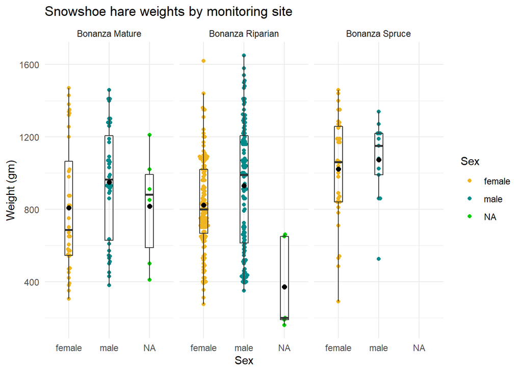

### Juvenile weight comparison (male and female snowshoe hares)

**Table 1** Descriptive statistics (mean, median, standard deviation, and sample size) between female and male snowshoe hares. Data: Kielland et al. 2017.

| Sex | Mean weight (gm) | Median weight (gm) | Standard deviation (gm) | Sample size |
| --- | --- | --- | --- | --- |
| female | 855.3909 | 825 | 292.2526 | 197 |
| male | 945.8589 | 990 | 333.2151 | 163 |